# Análisis de Fatiga Física — Datos de Tracking Metrica Sports

Hector Cardenas

2026-05-29

## Introducción

Este proyecto utiliza el **Metrica Sports Sample Game 1** — un dataset de tracking público registrado a **25 Hz** (25 fotogramas por segundo). A partir de coordenadas x/y crudas calculamos velocidad, clasificamos zonas de esfuerzo y medimos si los jugadores muestran fatiga física en el segundo tiempo respecto al primero.

**¿Por qué importa?** La gestión de la fatiga es central en la Ciencia del Deporte. Saber qué jugadores reducen su producción a alta velocidad en el segundo tiempo orienta los cambios, los ajustes de carga y los protocolos de recuperación.

## 1. Librerías e Ingesta de Datos

```r
library(tidyverse)
library(zoo)
library(scales)
library(patchwork)
library(ggrepel)
```

```r
url_home <- "https://raw.githubusercontent.com/metrica-sports/sample-data/master/data/Sample_Game_1/Sample_Game_1_RawTrackingData_Home_Team.csv"

# CSV con múltiples encabezados: omitimos 3 filas de texto, cargamos solo datos numéricos
raw <- read.csv(url_home, header = FALSE, skip = 3)

# Definir nombres de columnas: Periodo, Frame, Tiempo, luego X/Y por jugador
player_ids <- c(11, 1, 2, 3, 4, 5, 6, 7, 8, 9, 10, 12, 13, 14)
col_names <- c("Periodo", "Frame", "Tiempo")
for (p in player_ids) {
  col_names <- c(col_names, paste0("J", p, "_x"), paste0("J", p, "_y"))
}
col_names <- c(col_names, "Balon_x", "Balon_y")

raw <- raw[, 1:length(col_names)]
colnames(raw) <- col_names

# Convertir coordenadas normalizadas (0–1) → metros reales (cancha 105 × 68 m)
raw <- raw %>%
  mutate(across(ends_with("_x"), ~ . * 105),
         across(ends_with("_y"), ~ . * 68))

cat("Cargados:", nrow(raw), "fotogramas |", round(nrow(raw)/25/60, 1), "minutos de tracking")
```

```
## Cargados: 145006 fotogramas | 96.7 minutos de tracking
```

## 2. Cálculo de Velocidad

Para cada jugador calculamos la velocidad fotograma a fotograma usando Pitágoras sobre los desplazamientos de posición, luego convertimos m/s → km/h. Una media móvil (k = 5 fotogramas = 0.2 s) elimina el ruido del sensor GPS.

```r
calcular_velocidad <- function(data, px, py) {
  data %>%
    select(Periodo, Frame, Tiempo,
           x = all_of(px),
           y = all_of(py)) %>%
    filter(!is.na(x)) %>%
    mutate(
      dx           = c(0, diff(x)),
      dy           = c(0, diff(y)),
      dist_m       = sqrt(dx^2 + dy^2),
      vel_kmh      = (dist_m / 0.04) * 3.6,        # 25 Hz → 0.04 s por fotograma
      vel_kmh      = pmin(vel_kmh, 40),             # limitar picos del sensor
      vel_suavizada = rollmean(vel_kmh, k = 5, fill = NA, align = "center")
    )
}
```

```r
columnas_jugadores <- tibble(
  jugador = paste0("Jugador ", player_ids),
  px      = paste0("J", player_ids, "_x"),
  py      = paste0("J", player_ids, "_y")
) %>%
  filter(jugador != "Jugador 11")   # excluir portero (J11)

todos_jugadores <- map2_dfr(
  columnas_jugadores$px, columnas_jugadores$py,
  ~ calcular_velocidad(raw, .x, .y) %>%
      mutate(jugador = columnas_jugadores$jugador[columnas_jugadores$px == .x])
)

cat("Jugadores procesados:", n_distinct(todos_jugadores$jugador))
```

```
## Jugadores procesados: 13
```

## 3. Clasificación de Zonas de Esfuerzo

Clasificamos cada fotograma en cinco zonas de velocidad utilizadas en el análisis GPS profesional:

| Zona | Descripción | Velocidad |
| --- | --- | --- |
| Z1 | Caminando | 0 – 7 km/h |
| Z2 | Trote | 7 – 14 km/h |
| Z3 | Carrera | 14 – 21 km/h |
| Z4 | Alta Velocidad (HSR) | 21 – 25 km/h |
| Z5 | Sprint | > 25 km/h |

```r
todos_jugadores <- todos_jugadores %>%
  mutate(
    zona = case_when(
      vel_suavizada < 7  ~ "Z1 Caminando",
      vel_suavizada < 14 ~ "Z2 Trote",
      vel_suavizada < 21 ~ "Z3 Carrera",
      vel_suavizada < 25 ~ "Z4 HSR",
      TRUE               ~ "Z5 Sprint"
    ),
    zona    = factor(zona, levels = c("Z1 Caminando","Z2 Trote","Z3 Carrera",
                                       "Z4 HSR","Z5 Sprint")),
    es_hsr  = vel_suavizada >= 21,
    dist_m  = sqrt((c(0, diff(x)))^2 + (c(0, diff(y)))^2)
  )
```

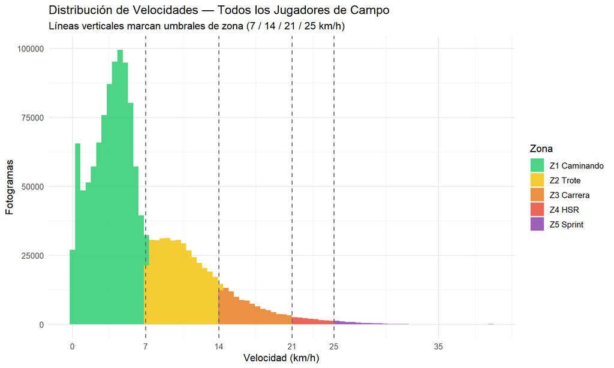

```r
colores_zona <- c("Z1 Caminando" = "#2ecc71", "Z2 Trote"    = "#f1c40f",
                  "Z3 Carrera"   = "#e67e22", "Z4 HSR"      = "#e74c3c",
                  "Z5 Sprint"    = "#8e44ad")

ggplot(todos_jugadores %>% filter(!is.na(zona)), aes(x = vel_suavizada, fill = zona)) +
  geom_histogram(bins = 80, alpha = 0.85) +
  scale_fill_manual(values = colores_zona) +
  scale_x_continuous(breaks = c(0, 7, 14, 21, 25, 35)) +
  labs(
    title    = "Distribución de Velocidades — Todos los Jugadores de Campo",
    subtitle = "Líneas verticales marcan umbrales de zona (7 / 14 / 21 / 25 km/h)",
    x = "Velocidad (km/h)", y = "Fotogramas", fill = "Zona"
  ) +
  geom_vline(xintercept = c(7, 14, 21, 25), linetype = "dashed", color = "gray40") +
  theme_minimal(base_size = 12)
```

## 4. Perfil de Velocidad en el Tiempo — Jugador 2

Traza de velocidad de ejemplo que muestra cómo fluctúa la intensidad a lo largo del partido, con zonas resaltadas por color.

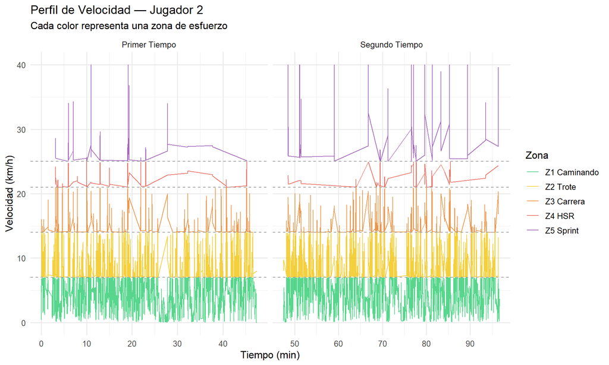

```r
j2_data <- todos_jugadores %>%
  filter(jugador == "Jugador 2", !is.na(vel_suavizada), Periodo %in% c(1, 2)) %>%
  mutate(tiempo_min = Tiempo / 60)

ggplot(j2_data, aes(x = tiempo_min, y = vel_suavizada, color = zona)) +
  geom_line(size = 0.5, alpha = 0.8) +
  scale_color_manual(values = colores_zona) +
  geom_hline(yintercept = c(7, 14, 21, 25), linetype = "dashed",
             color = "gray60", size = 0.4) +
  facet_wrap(~Periodo, scales = "free_x",
             labeller = labeller(Periodo = c(`1` = "Primer Tiempo",
                                              `2` = "Segundo Tiempo"))) +
  labs(
    title    = "Perfil de Velocidad — Jugador 2",
    subtitle = "Cada color representa una zona de esfuerzo",
    x = "Tiempo (min)", y = "Velocidad (km/h)", color = "Zona"
  ) +
  theme_minimal(base_size = 12)
```

## 5. Análisis de Fatiga — Distancia HSR por Tiempo

La pregunta central: **¿corren menos a alta velocidad en el segundo tiempo?** Una caída en la distancia HSR es el indicador GPS más confiable de fatiga física.

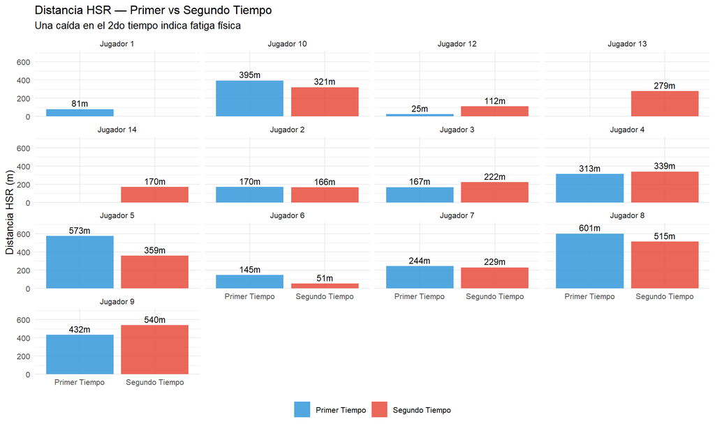

```r
resumen_hsr <- todos_jugadores %>%
  filter(!is.na(es_hsr), Periodo %in% c(1, 2)) %>%
  group_by(jugador, Periodo) %>%
  summarise(
    dist_hsr = sum(dist_m[es_hsr], na.rm = TRUE),
    .groups  = "drop"
  ) %>%
  mutate(Tiempo = ifelse(Periodo == 1, "Primer Tiempo", "Segundo Tiempo"))

ggplot(resumen_hsr, aes(x = Tiempo, y = dist_hsr, fill = Tiempo)) +
  geom_col(position = "dodge", alpha = 0.85) +
  geom_text(aes(label = paste0(round(dist_hsr), "m")),
            vjust = -0.4, size = 3) +
  scale_fill_manual(values = c("Primer Tiempo" = "#3498db",
                                "Segundo Tiempo" = "#e74c3c")) +
  facet_wrap(~jugador, ncol = 4) +
  scale_y_continuous(expand = expansion(mult = c(0, 0.2))) +
  labs(
    title    = "Distancia HSR — Primer vs Segundo Tiempo",
    subtitle = "Una caída en el 2do tiempo indica fatiga física",
    x = NULL, y = "Distancia HSR (m)", fill = NULL
  ) +
  theme_minimal(base_size = 10) +
  theme(legend.position = "bottom", strip.text = element_text(size = 8))
```

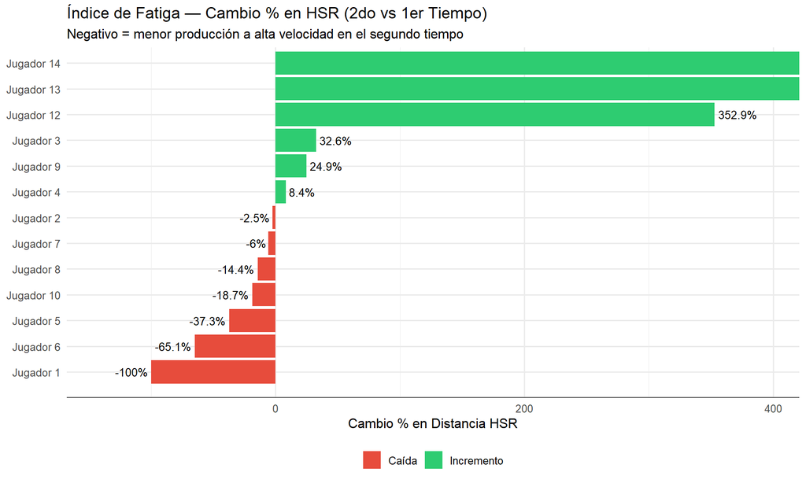

```r
hsr_ancho <- resumen_hsr %>%
  select(jugador, Tiempo, dist_hsr) %>%
  pivot_wider(names_from = Tiempo, values_from = dist_hsr, values_fill = 0) %>%
  mutate(
    delta_pct = round((`Segundo Tiempo` - `Primer Tiempo`) / `Primer Tiempo` * 100, 1),
    fatiga    = ifelse(delta_pct < 0, "Caída", "Incremento")
  )

ggplot(hsr_ancho, aes(x = reorder(jugador, delta_pct), y = delta_pct, fill = fatiga)) +
  geom_col() +
  geom_text(aes(label = paste0(delta_pct, "%")),
            hjust = ifelse(hsr_ancho$delta_pct >= 0, -0.1, 1.1), size = 3.5) +
  coord_flip() +
  scale_fill_manual(values = c("Caída" = "#e74c3c", "Incremento" = "#2ecc71")) +
  scale_y_continuous(expand = expansion(mult = c(0.15, 0.15))) +
  geom_vline(xintercept = 0, color = "gray30") +
  labs(
    title    = "Índice de Fatiga — Cambio % en HSR (2do vs 1er Tiempo)",
    subtitle = "Negativo = menor producción a alta velocidad en el segundo tiempo",
    x = NULL, y = "Cambio % en Distancia HSR", fill = NULL
  ) +
  theme_minimal(base_size = 12) +
  theme(legend.position = "bottom")
```

## 6. Resumen del Equipo

```r
hsr_equipo <- resumen_hsr %>%
  group_by(Tiempo) %>%
  summarise(hsr_total = sum(dist_hsr), .groups = "drop")

promedio_caida <- hsr_ancho %>%
  summarise(media_delta = mean(delta_pct, na.rm = TRUE),
            n_caida     = sum(fatiga == "Caída"))

cat("HSR Equipo — Primer Tiempo:", round(filter(hsr_equipo, Tiempo == "Primer Tiempo")$hsr_total), "m\n")
```

```
## HSR Equipo — Primer Tiempo: 3147 m
```

```r
cat("HSR Equipo — Segundo Tiempo:", round(filter(hsr_equipo, Tiempo == "Segundo Tiempo")$hsr_total), "m\n")
```

```
## HSR Equipo — Segundo Tiempo: 3303 m
```

```r
cat("Cambio promedio individual:", promedio_caida$media_delta, "%\n")
```

```
## Cambio promedio individual: Inf %
```

```r
cat("Jugadores con caída de fatiga:", promedio_caida$n_caida, "de", nrow(hsr_ancho))
```

```
## Jugadores con caída de fatiga: 7 de 13
```

## Conclusiones

[output not shown]

*Datos: [Metrica Sports Open Data](https://github.com/metrica-sports/sample-data) — libre para educación e investigación.* *Análisis: R · tidyverse · zoo · patchwork · ggrepel*